# The Story Behind The 2020 U.S. Presidential Election: A Big Data Analysis using Social Media - Data Analysis

Team C

3/3/2021

# Data sets

We are going use three datasets in this project. These datasets will cover the period before the election (approval rate data), period during the election (US Election 2020 Tweets), and last dataset for the actual election results (1976-2020-president). The following section will elaborate more on these dataseta and the main role for each one.

## approval rate data

loading the dataset

```r
approval.rate <- read_csv("Data/approval_topline.csv")
```

Based on the table below, data is clean and there is no null or not avialable data.

```r
summary(approval.rate)
```

```
##   president           subgroup          modeldate         approve_estimate
##  Length:4377        Length:4377        Length:4377        Min.   :34.93
##  Class :character   Class :character   Class :character   1st Qu.:40.31
##  Mode  :character   Mode  :character   Mode  :character   Median :41.62
##                                                           Mean   :41.46
##                                                           3rd Qu.:42.86
##                                                           Max.   :48.62
##    approve_hi      approve_lo    disapprove_estimate disapprove_hi
##  Min.   :38.82   Min.   :31.04   Min.   :37.00       Min.   :43.29
##  1st Qu.:44.31   1st Qu.:36.12   1st Qu.:52.54       1st Qu.:56.75
##  Median :46.01   Median :37.44   Median :53.39       Median :57.70
##  Mean   :45.75   Mean   :37.18   Mean   :53.49       Mean   :57.85
##  3rd Qu.:47.24   3rd Qu.:38.52   3rd Qu.:54.54       3rd Qu.:58.99
##  Max.   :53.80   Max.   :43.43   Max.   :60.59       Max.   :65.84
##  disapprove_lo    timestamp
##  Min.   :30.71   Length:4377
##  1st Qu.:48.30   Class :character
##  Median :49.14   Mode  :character
##  Mean   :49.13
##  3rd Qu.:50.20
##  Max.   :55.33
```

```r
names(approval.rate)
```

```
##  [1] "president"           "subgroup"            "modeldate"
##  [4] "approve_estimate"    "approve_hi"          "approve_lo"
##  [7] "disapprove_estimate" "disapprove_hi"       "disapprove_lo"
## [10] "timestamp"
```

```r
dim(approval.rate)
```

```
## [1] 4377   10
```

## Election Results

```r
election.results <- read_csv("Data/1976-2020-president.csv")
summary(election.results)
```

```
##       year         state             state_po           state_fips
##  Min.   :1976   Length:4287        Length:4287        Min.   : 1.00
##  1st Qu.:1988   Class :character   Class :character   1st Qu.:16.00
##  Median :2000   Mode  :character   Mode  :character   Median :28.00
##  Mean   :1999                                         Mean   :28.62
##  3rd Qu.:2012                                         3rd Qu.:41.00
##  Max.   :2020                                         Max.   :56.00
##    state_cen        state_ic        office           candidate
##  Min.   :11.00   Min.   : 1.00   Length:4287        Length:4287
##  1st Qu.:33.00   1st Qu.:22.00   Class :character   Class :character
##  Median :53.00   Median :42.00   Mode  :character   Mode  :character
##  Mean   :53.67   Mean   :39.75
##  3rd Qu.:81.00   3rd Qu.:61.00
##  Max.   :95.00   Max.   :82.00
##  party_detailed      writein        candidatevotes       totalvotes
##  Length:4287        Mode :logical   Min.   :       0   Min.   :  123574
##  Class :character   FALSE:3807      1st Qu.:    1177   1st Qu.:  652274
##  Mode  :character   TRUE :477       Median :    7499   Median : 1569180
##                     NA's :3         Mean   :  311908   Mean   : 2366924
##                                     3rd Qu.:  199242   3rd Qu.: 3033118
##                                     Max.   :11110250   Max.   :17500881
##     version          notes         party_simplified
##  Min.   :20210113   Mode:logical   Length:4287
##  1st Qu.:20210113   NA's:4287      Class :character
##  Median :20210113                  Mode  :character
##  Mean   :20210113
##  3rd Qu.:20210113
##  Max.   :20210113
```

```r
names(election.results)
```

```
##  [1] "year"             "state"            "state_po"         "state_fips"
##  [5] "state_cen"        "state_ic"         "office"           "candidate"
##  [9] "party_detailed"   "writein"          "candidatevotes"   "totalvotes"
## [13] "version"          "notes"            "party_simplified"
```

```r
dim(election.results)
```

```
## [1] 4287   15
```

## US Election 2020 Tweets

The “U.S. election 2020 Tweets” is the main dataset for this project. The dataset contains Tweets collected using Twitter API during the most critical period in the presidency election race. Tweets are splited into 2 CSV files. The first file contains all tweets with hastag related to election and Donald Trump while the other one contains tweets with hashtag for Joe Biden. Both files cover the period from 15th-Oct 2020 to 8th-Nov-2020. Dataset contains many other useful information beside tweet text as number of like, number of retweets, user location (continent, country, state…etc.), user name on tweeter and some other useful information. The following paragraph will share some statisctics on this data sets.

**Dataset name:** US Election 2020 Tweets **Description:** Tweets collected, using the Twitter API statuses_lookup and snsscrape during the election period. The dataset contains 2 files, one of the former president “Donald Trump” and the other one for tweets related to the current president “Joe Biden”.

### Data profiling and exploration

#### Loading data

**File # 1**: hashtag_donaldtrump.csv Importing tweets that contain hashtag “**Donald Trump**”. A new column “hashtag” with static value “Trump” been added to distinguage between data loaded from this file

```r
Trump <- read_csv("Data/hashtag_donaldtrump.csv")
Trump$hashtag <-"Trump"
```

**File # 2:** hashtag_joebiden.csv Importing tweets that contain hashtag “**Joe Biden**”. A new column “hashtag” with static value “Biden” been added to distinguage between data loaded from this file

```r
Biden <- read_csv("Data/hashtag_joebiden.csv")
Biden$hashtag <- "Biden"
Biden[['created_at']] <- as.Date(Biden[['created_at']], format='%Y-%m-%d  %H:%M:%S')
Biden.Trump.merged <- rbind(Trump,Biden)
```

We have a small problem with data type for “created_at” feature in the biden CSV file as it was stored as string and we want to convert that to date.

```r
Biden[['created_at']] <- as.Date(Biden[['created_at']], format='%Y-%m-%d  %H:%M:%S')
Biden.Trump.merged <- rbind(Trump,Biden)
```

Finally we want to merge both datasets into one consolidate dataset.

```r
Biden.Trump.merged <- rbind(Trump,Biden)
```

**Note(s):** + We can see small number of tweets faild to load around 1000 records out of 2 million records.

#### Profiling the consolidated dataset

There is around 2 Million records / tweets in the first dataset (1,748,160) and 22 variable.

```r
dim(Biden.Trump.merged)
```

```
## [1] 1748160      22
```

Thoes variables are described below:

```r
names(Biden.Trump.merged)
```

```
##  [1] "created_at"           "tweet_id"             "tweet"
##  [4] "likes"                "retweet_count"        "source"
##  [7] "user_id"              "user_name"            "user_screen_name"
## [10] "user_description"     "user_join_date"       "user_followers_count"
## [13] "user_location"        "lat"                  "long"
## [16] "city"                 "country"              "continent"
## [19] "state"                "state_code"           "collected_at"
## [22] "hashtag"
```

The following paragraph shows summary information about each variable

```r
summary(Biden.Trump.merged)
```

```
##    created_at                    tweet_id            tweet
##  Min.   :2020-10-15 00:00:00   Length:1748160     Length:1748160
##  1st Qu.:2020-10-26 00:00:00   Class :character   Class :character
##  Median :2020-11-03 22:54:07   Mode  :character   Mode  :character
##  Mean   :2020-10-31 15:34:46
##  3rd Qu.:2020-11-06 09:53:05
##  Max.   :2020-11-08 23:59:56
##  NA's   :355
##      likes           retweet_count          source             user_id
##  Min.   :     0.00   Min.   :0.000e+00   Length:1748160     Min.   :5.310e+02
##  1st Qu.:     0.00   1st Qu.:0.000e+00   Class :character   1st Qu.:2.204e+08
##  Median :     0.00   Median :0.000e+00   Mode  :character   Median :2.409e+09
##  Mean   :     8.67   Mean   :4.595e+12                      Mean   :4.497e+17
##  3rd Qu.:     2.00   3rd Qu.:0.000e+00                      3rd Qu.:1.083e+18
##  Max.   :165702.00   Max.   :1.323e+18                      Max.   :1.326e+18
##  NA's   :365         NA's   :332                            NA's   :365
##   user_name         user_screen_name   user_description
##  Length:1748160     Length:1748160     Length:1748160
##  Class :character   Class :character   Class :character
##  Mode  :character   Mode  :character   Mode  :character
##
##
##
##
##  user_join_date                user_followers_count user_location
##  Min.   :1970-01-01 00:00:00   Length:1748160       Length:1748160
##  1st Qu.:2010-11-27 15:34:06   Class :character     Class :character
##  Median :2014-03-20 17:52:59   Mode  :character     Mode  :character
##  Mean   :2014-09-20 18:34:26
##  3rd Qu.:2019-01-11 04:03:05
##  Max.   :2020-11-08 23:29:53
##  NA's   :618
##       lat              long            city             country
##  Min.   :-90.0    Min.   :-175.2   Length:1748160     Length:1748160
##  1st Qu.: 31.8    1st Qu.: -97.1   Class :character   Class :character
##  Median : 39.8    Median : -74.0   Mode  :character   Mode  :character
##  Mean   : 35.4    Mean   : -41.1
##  3rd Qu.: 45.5    3rd Qu.:   6.1
##  Max.   : 90.0    Max.   : 179.0
##  NA's   :947178   NA's   :947178
##   continent            state            state_code
##  Length:1748160     Length:1748160     Length:1748160
##  Class :character   Class :character   Class :character
##  Mode  :character   Mode  :character   Mode  :character
##
##
##
##
##   collected_at                   hashtag
##  Min.   :2020-10-21 00:00:00   Length:1748160
##  1st Qu.:2020-10-27 18:30:18   Class :character
##  Median :2020-11-05 12:06:00   Mode  :character
##  Mean   :2020-11-02 15:44:23
##  3rd Qu.:2020-11-07 11:40:25
##  Max.   :2020-11-09 18:40:08
##  NA's   :618
```

We can observe a hug number of null values in “lat” and “Long” columns, so we need to assess if this will impact our future analysis.

The following paragraph show the data strucure for the consiloidated dataset

```r
str(Biden.Trump.merged)
```

```
## tibble [1,748,160 x 22] (S3: spec_tbl_df/tbl_df/tbl/data.frame)
##  $ created_at          : POSIXct[1:1748160], format: "2020-10-15 00:00:01" "2020-10-15 00:00:01" ...
##  $ tweet_id            : chr [1:1748160] "1316529221557252096" "1316529222748430336" "1316529228091846912" "1316529227471237120" ...
##  $ tweet               : chr [1:1748160] "#Elecciones2020 | En #Florida: #JoeBiden dice que #DonaldTrump solo se preocupa por él mismo. El demócrata fue "| __truncated__ "Usa 2020, Trump contro Facebook e Twitter: coprono Biden   #donaldtrump https://t.co/6ceURhe1VP https://t.co/94jidLjoON" "#Tru…
##  $ likes               : num [1:1748160] 0 26 2 0 4 2 0 0 0 0 ...
##  $ retweet_count       : num [1:1748160] 0 9 1 0 3 0 0 0 0 0 ...
##  $ source              : chr [1:1748160] "TweetDeck" "Social Mediaset" "Twitter Web App" "Trumpytweeter" ...
##  $ user_id             : num [1:1748160] 3.61e+08 3.32e+08 8.44e+06 8.28e+17 4.74e+07 ...
##  $ user_name           : chr [1:1748160] "El Sol Latino News" "Tgcom24" "snarke" "Trumpytweeter" ...
##  $ user_screen_name    : chr [1:1748160] "elsollatinonews" "MediasetTgcom24" "snarke" "trumpytweeter" ...
##  $ user_description    : chr [1:1748160] "🌐 Noticias de interés para latinos de la costa este de #EEUU\n⠀⏹️ Facebook e In"| __truncated__ "Profilo ufficiale di Tgcom24: tutte le notizie sul sito https://t.co/sC5iMbymSN e sul canale 51 del digitale terrestre" "Will mock for food! Freelance writer,…
##  $ user_join_date      : POSIXct[1:1748160], format: "2011-08-23 15:33:45" "2011-07-08 13:12:20" ...
##  $ user_followers_count: chr [1:1748160] "1860" "1067661" "1185" "32" ...
##  $ user_location       : chr [1:1748160] "Philadelphia, PA / Miami, FL" NA "Portland" NA ...
##  $ lat                 : num [1:1748160] 25.8 NA 45.5 NA 38.9 ...
##  $ long                : num [1:1748160] -80.2 NA -122.7 NA -77 ...
##  $ city                : chr [1:1748160] NA NA "Portland" NA ...
##  $ country             : chr [1:1748160] "United States of America" NA "United States of America" NA ...
##  $ continent           : chr [1:1748160] "North America" NA "North America" NA ...
##  $ state               : chr [1:1748160] "Florida" NA "Oregon" NA ...
##  $ state_code          : chr [1:1748160] "FL" NA "OR" NA ...
##  $ collected_at        : POSIXct[1:1748160], format: "2020-10-21 00:00:00" "2020-10-21 00:00:00" ...
##  $ hashtag             : chr [1:1748160] "Trump" "Trump" "Trump" "Trump" ...
##  - attr(*, "problems")= tibble [955 x 5] (S3: tbl_df/tbl/data.frame)
##   ..$ row     : int [1:955] 2025 2026 2026 2026 2026 6020 6021 6021 6021 6021 ...
##   ..$ col     : chr [1:955] NA "created_at" "tweet_id" "user_followers_count" ...
##   ..$ expected: chr [1:955] "21 columns" "date like " "no trailing characters" "no trailing characters" ...
##   ..$ actual  : chr [1:955] "10 columns" "US NAVAL AIR - E-2 HAWKEYE PILOT - ADVENTURE OF A LIFETIME - SEE LINK." "2016-11-10 06:58:20" "2020-10-21 00:12:47.706402996" ...
##   ..$ file    : chr [1:955] "'Data/hashtag_donaldtrump.csv'" "'Data/hashtag_donaldtrump.csv'" "'Data/hashtag_donaldtrump.csv'" "'Data/hashtag_donaldtrump.csv'" ...
##  - attr(*, "spec")=
##   .. cols(
##   ..   created_at = col_datetime(format = ""),
##   ..   tweet_id = col_double(),
##   ..   tweet = col_character(),
##   ..   likes = col_double(),
##   ..   retweet_count = col_double(),
##   ..   source = col_character(),
##   ..   user_id = col_double(),
##   ..   user_name = col_character(),
##   ..   user_screen_name = col_character(),
##   ..   user_description = col_character(),
##   ..   user_join_date = col_datetime(format = ""),
##   ..   user_followers_count = col_double(),
##   ..   user_location = col_character(),
##   ..   lat = col_double(),
##   ..   long = col_double(),
##   ..   city = col_character(),
##   ..   country = col_character(),
##   ..   continent = col_character(),
##   ..   state = col_character(),
##   ..   state_code = col_character(),
##   ..   collected_at = col_datetime(format = "")
##   .. )
```

#### Histogram for the most important columns

##### created_at

This column show the date of creation for each tweet. we want to make sure that it doens’t contain null or unexpected information. The follwoing graph show number of tweets per month:

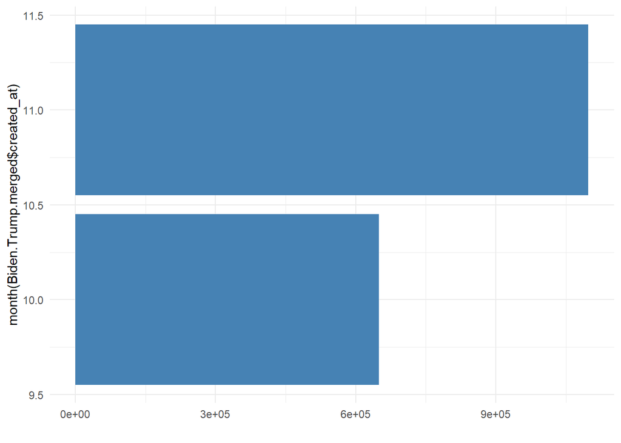

```r
created_at_month.p<- qplot(month(Biden.Trump.merged$created_at), data = Biden.Trump.merged)
created_at_month.p + coord_flip() + geom_bar( fill="steelblue") + theme_minimal()
```

```r
#+ geom_text()
```

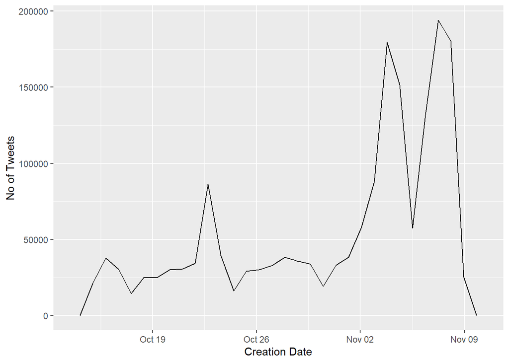

```r
qplot(data = Biden.Trump.merged, x=Biden.Trump.merged$created_at, xlab="Creation Date"
      , ylab ="No of Tweets" , geom = "freqpoly" )
```

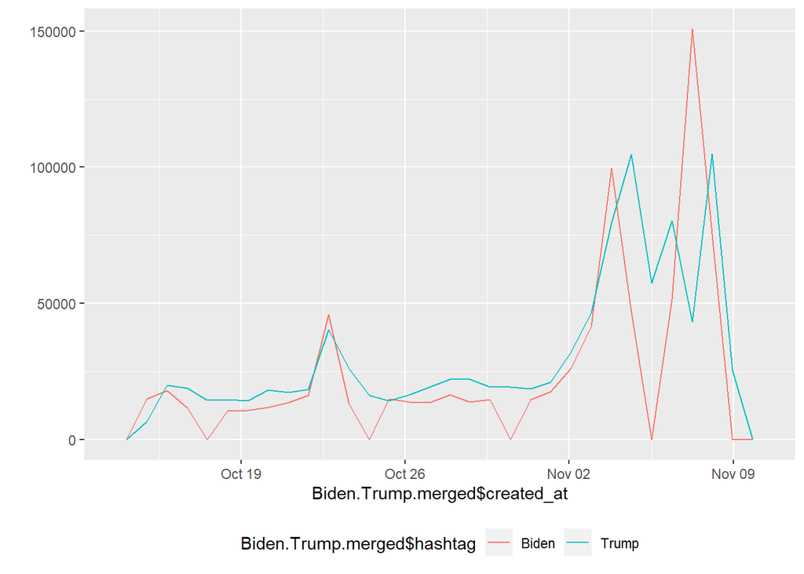

```r
qplot(Biden.Trump.merged$created_at, data = Biden.Trump.merged, geom = "freqpoly", fill="steelblue", color=Biden.Trump.merged$hashtag)+theme(legend.position="bottom")
```

```r
#+ labs(title="Number of tweets by Creation date", x ="Created at", y = "No. of tweets")
```

##### Geographical Information

The next task is to analyis geographocal information that we have in this dataset

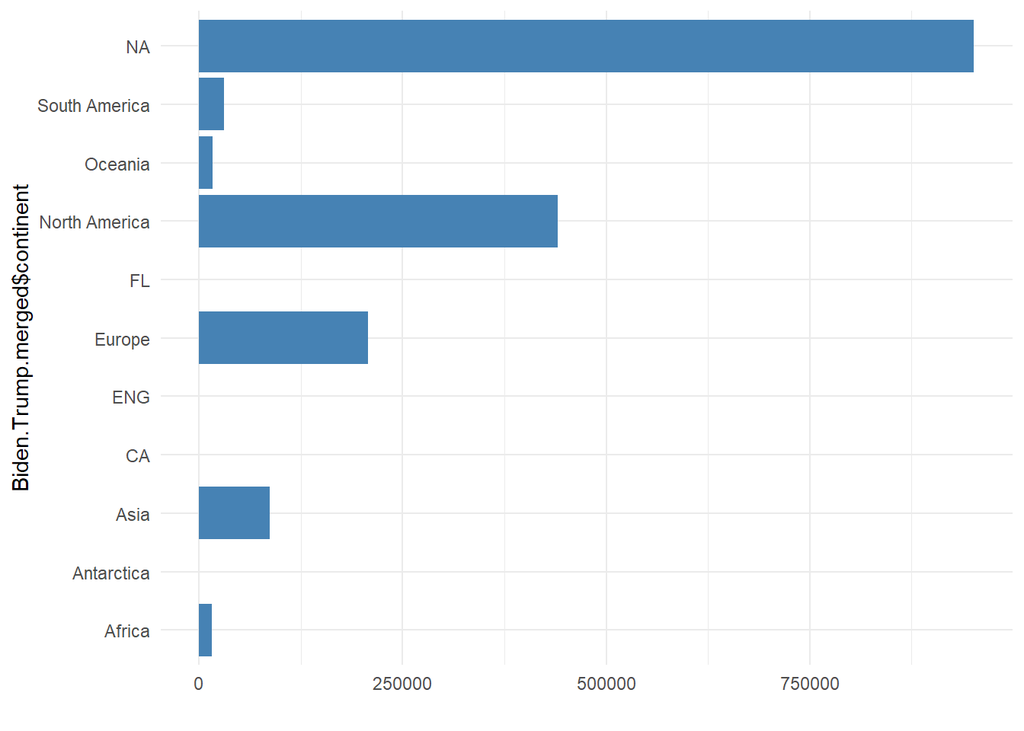

```r
continent.p<- qplot(Biden.Trump.merged$continent, data = Biden.Trump.merged)
continent.p + coord_flip() + geom_bar( fill="steelblue") + theme_minimal()
```

```r
#+ geom_text(aes(label=continent))
```

As we can see, there are many null values in the continent column. The next chart will show number iof tweets after removing all null values

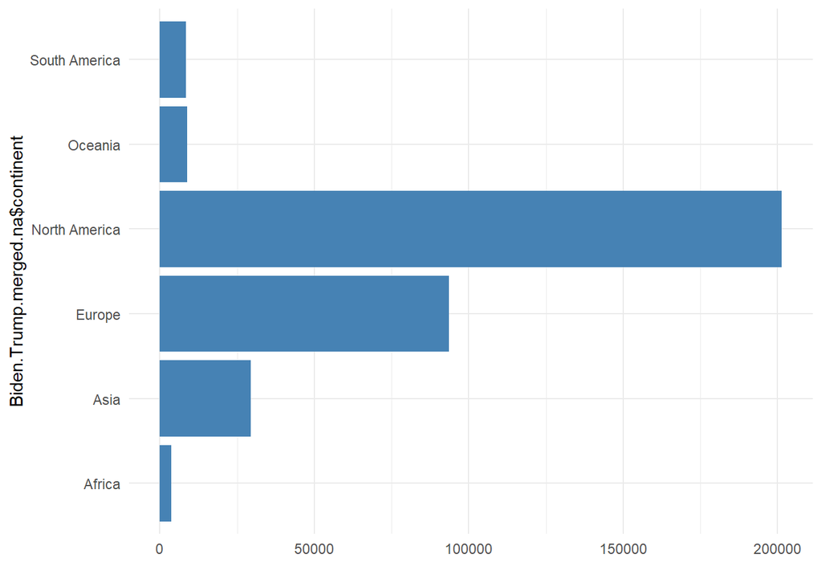

```r
Biden.Trump.merged.na<- drop_na(Biden.Trump.merged)
qplot(Biden.Trump.merged.na$continent, data = Biden.Trump.merged.na ) + coord_flip() + geom_bar( fill="steelblue") + theme_minimal()
```

```r
#+ geom_text(aes(label=continent))
```

Let’s examine the Country distinct values to make sure that we done’t have data quality issues in that column.

```r
unique(filter(Biden.Trump.merged, substr(Biden.Trump.merged$country,1,6) == "United")$country)
```

```
## [1] "United States of America" "United Kingdom"
## [3] "United States"            "United Arab Emirates"
```

We can see that we have a data quality issue here as United States stored in the dataset using two different values + United States of America + United States To fix that we will replace “United States of America” values with “United States” value.

```r
Biden.Trump.merged$country[Biden.Trump.merged$country == "United States of America"] <- "United States"
```

Now, we have only one value to represent **“United States”**

```r
unique(filter(Biden.Trump.merged, substr(Biden.Trump.merged$country,1,6) == "United")$country)
```

```
## [1] "United States"        "United Kingdom"       "United Arab Emirates"
```

Now let’s check Stats of the “United States” by state name:

```r
unique(filter(Biden.Trump.merged, Biden.Trump.merged$country == "United States")$state)
```

```
##  [1] "Florida"                  "Oregon"
##  [3] "District of Columbia"     "California"
##  [5] "Ohio"                     "Pennsylvania"
##  [7] "Illinois"                 "Michigan"
##  [9] NA                         "New Jersey"
## [11] "Massachusetts"            "New Hampshire"
## [13] "Texas"                    "South Dakota"
## [15] "Georgia"                  "Missouri"
## [17] "New York"                 "Colorado"
## [19] "South Carolina"           "Virginia"
## [21] "Alabama"                  "Arizona"
## [23] "North Carolina"           "Tennessee"
## [25] "Nebraska"                 "Louisiana"
## [27] "Nevada"                   "Minnesota"
## [29] "Indiana"                  "Washington"
## [31] "Hawaii"                   "West Virginia"
## [33] "Vermont"                  "Idaho"
## [35] "Puerto Rico"              "Iowa"
## [37] "Kentucky"                 "North Dakota"
## [39] "Arkansas"                 "Wisconsin"
## [41] "Utah"                     "Montana"
## [43] "Kansas"                   "Wyoming"
## [45] "Maine"                    "Connecticut"
## [47] "Maryland"                 "New Mexico"
## [49] "Oklahoma"                 "Alaska"
## [51] "Delaware"                 "Rhode Island"
## [53] "Mississippi"              "Guam"
## [55] "Northern Mariana Islands"
```

Now let’s check Stats of the “United States” by state code:

```r
unique(filter(Biden.Trump.merged, Biden.Trump.merged$country == "United States")$state_code)
```

```
##  [1] "FL" "OR" "DC" "CA" "OH" "PA" "IL" "MI" NA   "NJ" "MA" "NH" "TX" "SD" "GA"
## [16] "MO" "NY" "CO" "SC" "VA" "AL" "AZ" "NC" "TN" "NE" "LA" "NV" "MN" "IN" "WA"
## [31] "HI" "WV" "VT" "ID" "PR" "IA" "KY" "ND" "AR" "WI" "UT" "MT" "KS" "WY" "ME"
## [46] "CT" "MD" "NM" "OK" "AK" "DE" "RI" "MS" "GU" "MP"
```

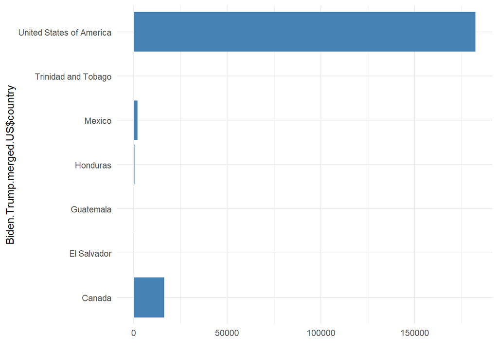

```r
Biden.Trump.merged.US<-filter(Biden.Trump.merged.na, continent == "North America")
qplot(Biden.Trump.merged.US$country, data = Biden.Trump.merged.US ) + coord_flip() + geom_bar( fill="steelblue") + theme_minimal()
```

```r
#+ geom_text(aes(label=continent))
```

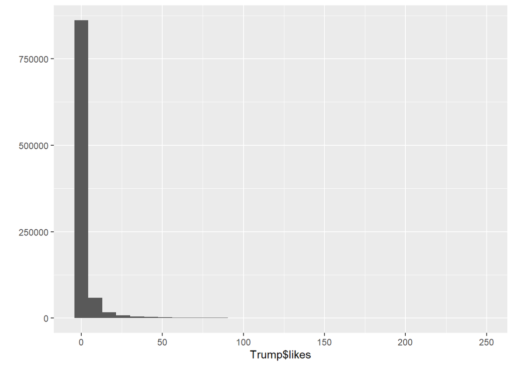

```r
qplot(Trump$likes, data = Trump) +
  #geom_point(alpha = 0.5, color="aquamarine4", position = position_jitter(h = 0))
 xlim(min(Trump$likes),250)
```

```r
#continent.p + coord_flip() + geom_bar( fill="steelblue") + theme_minimal()
#+ geom_text(aes(label=continent))
```

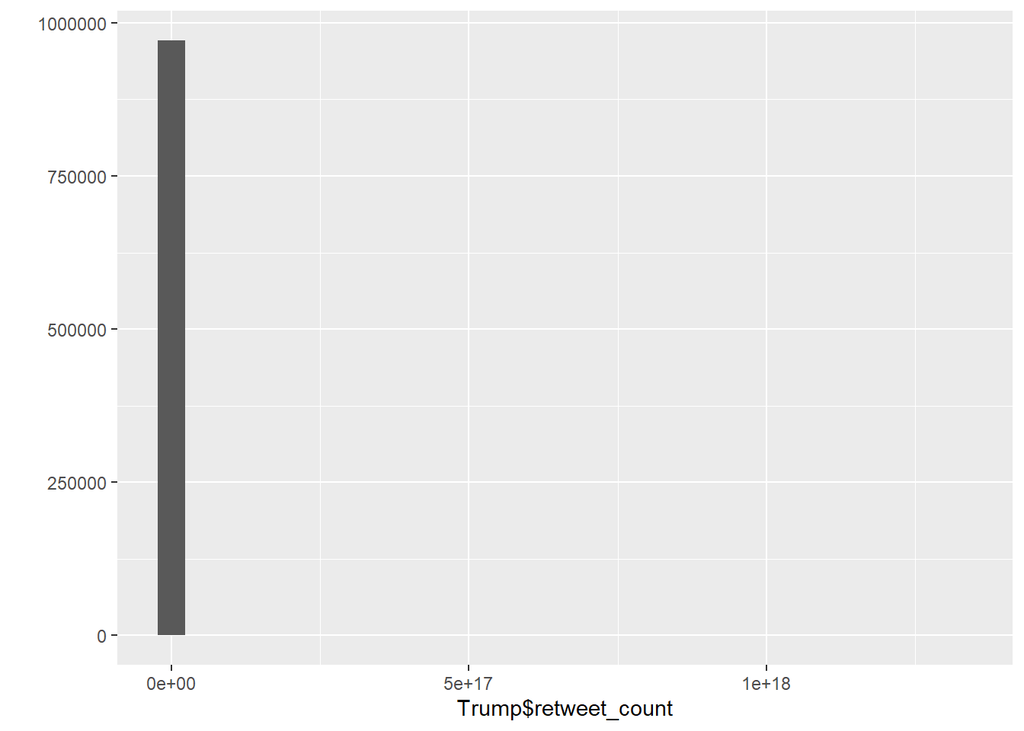

```r
qplot(Trump$retweet_count, data = Trump) #+
```

```r
  #geom_point(alpha = 0.5, color="aquamarine4", position = position_jitter(h = 0))
 xlim(min(Trump$retweet_coun),10000)
```

```
## <ScaleContinuousPosition>
##  Range:
##  Limits:    0 --    1
```

```r
#continent.p + coord_flip() + geom_bar( fill="steelblue") + theme_minimal()
#+ geom_text(aes(label=continent))
```

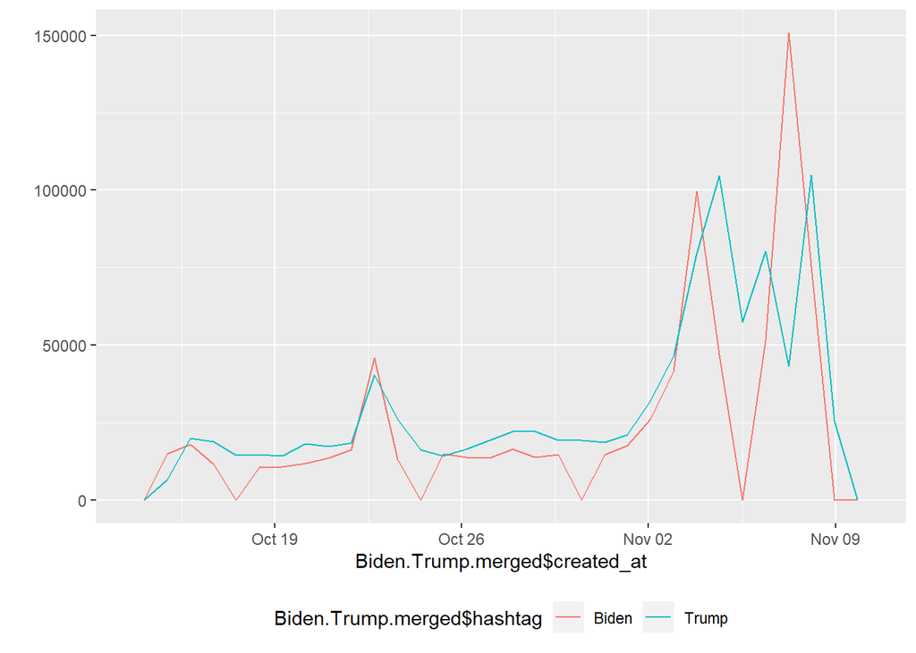

```r
qplot(Biden.Trump.merged$created_at, data = Biden.Trump.merged, geom = "freqpoly", fill="steelblue", color=Biden.Trump.merged$hashtag)+theme(legend.position="bottom")
```

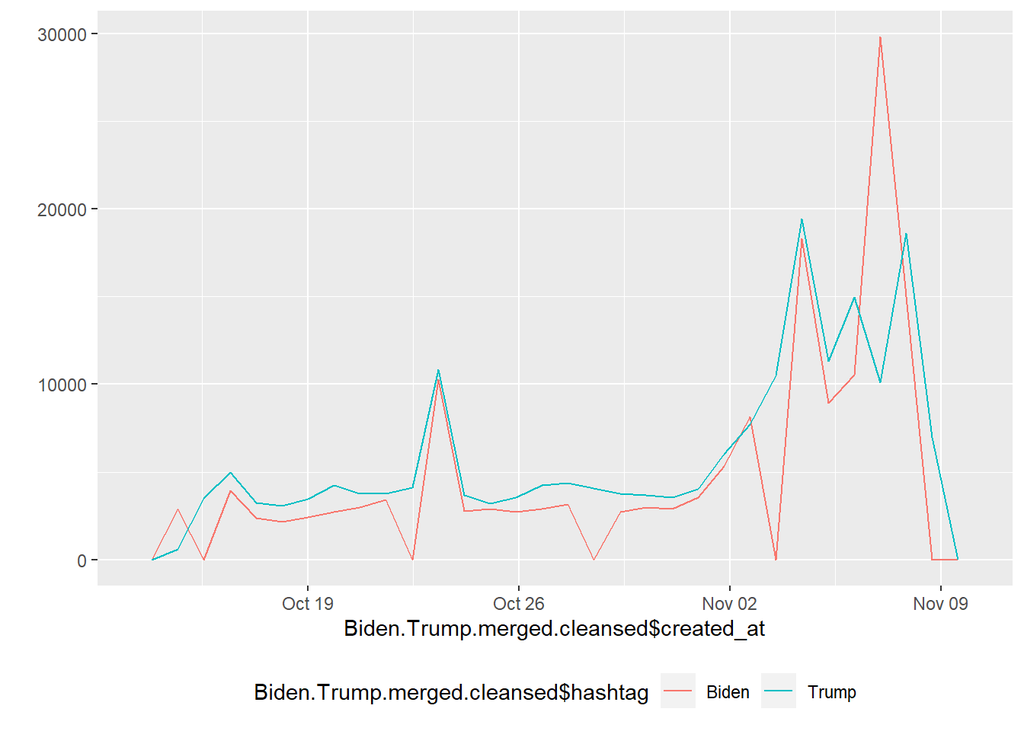

```r
Biden.Trump.merged.cleansed <- drop_na(Biden.Trump.merged)
qplot(Biden.Trump.merged.cleansed$created_at, data = Biden.Trump.merged.cleansed, geom = "freqpoly", fill="steelblue", color=Biden.Trump.merged.cleansed$hashtag)+theme(legend.position="bottom")
```